# Homework 8

Liu Huihang

10/22/2019

## Answer 1

### Data Preparation

We generate samples from binnomial distribution with proportion $0.3, 0.7$, whose values correspond to different distributions within the Bart Simpson distribution respectively.

```r
library(kedd)
set.seed(111)
pro <- c(0.3, 0.7)
multi <- sample(1:2, 100, replace = T, prob=pro)
mu <- c(0, 1)
sigma <- c(1, 0.3)
x <- NULL
for (ii in 1:2) {
  com_txt <- paste("com", ii, " <- rnorm(length(which(multi==", ii, ")), mean=", mu[ii], ", sd=", sigma[ii], ")",sep="")
  eval(parse(text=com_txt))
  com_txt <- paste("x <- c(x, com", ii, ")", sep="")
  eval(parse(text=com_txt))
}
```

### Bandwidth selection

We conside $h$ to optimize AMISE, maximum likelihood cross-validation,unbiased cross-calidation, biased cross-calidation, complete cross-calidation, modified cross-calidation,trimmed cross-calidation.

The values of these method is shown following,

```r
amise <- h.amise(x, deriv.order = 1)$h
mlcv <- h.mlcv(x, deriv.order = 1)$h;
ucv <- h.ucv(x, deriv.order = 1)$h;
bcv <- h.bcv(x, deriv.order = 1)$h;
ccv <- h.ccv(x, deriv.order = 1)$h;
mcv <- h.mcv(x, deriv.order = 1)$h;
tcv <-  h.tcv(x, deriv.order = 1)$h
h <- c(amise=amise, mlcv=mlcv, ucv=ucv, bcv=bcv, ccv=ccv, mcv=mcv,tcv=tcv)
print(round(h, 4))
```

```
##  amise   mlcv    ucv    bcv    ccv    mcv    tcv
## 0.6481 0.2010 0.2681 0.2193 0.0975 0.1093 0.4978
```

### Draw figure

We can generate DKDE by **dkde** function with defalut parameters and draw then in one figure as following.

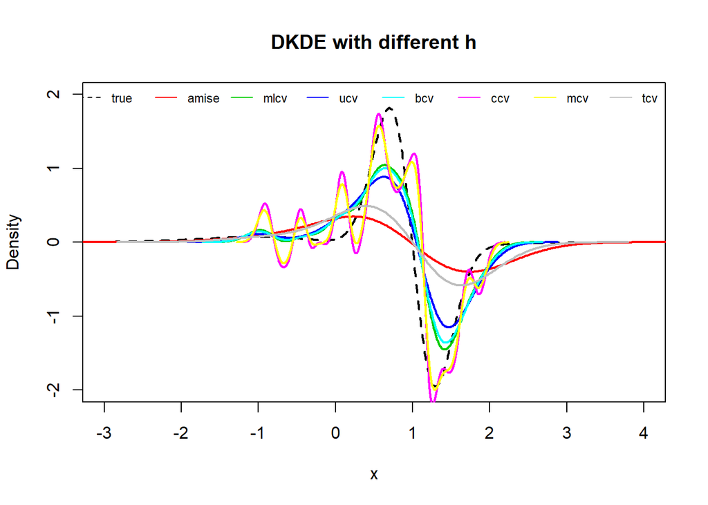

```r
y <- seq(-4, 4, 0.01)
z <- rep(0, length(y))
for (ii in 1:2) {
  z <- z + pro[ii] * dnorm(y, mean=mu[ii], sd=sigma[ii]) * (mu[ii]-y) / sigma[ii]^2
}
plot(y, z, "l", lty=2, lwd=2, col=1, xlab="x", ylab="Density" , xlim=c(-3,4), ylim=c(-2,2))
for (ii in 1:7) {
  lines(dkde(x, h=h[ii], deriv.order = 1), col=ii+1, lwd=2)
}
legend("top", ncol=8, bty="n", cex=0.72, legend=c("true","amise","mlcv","ucv","bcv","ccv","mcv","tcv"), col=1:8, lty=c(2, rep(1,7)))
title("DKDE with different h")
```

## Problem 2 (Homework 8.3)

Write program to draw the figure of 21 pages of courseware. (Referring algorithm steps in reading materials)

## Answer 2

### Data preparation

```r
set.seed(113)
n <- 100              # sample size
h <- 0.3
c <- 0.5              # default
x <- seq(1, 1500)/100 # real sequence
density <- dlnorm(x)  # true density function
X <- rlnorm(n)
```

### Sample point KDE

We use the algorithem intruducted in reference material.

1. Calculate $\hat{f}(x, h)$ in the usual way.
2. Determine a modification parameter $s_i, i = 1, 2, \dots , n$, as
   $$\begin{equation}
   s_{i}=\left(\frac{\hat{f}\left(X_{i}, h\right)}{T}\right)^{-c}
   \end{equation}$$
   where $c \ge 0$ and T is the geometric mean of the values of the KDE of all data points, that is $\hat{f}(X_i, h)$ and
   $$\begin{equation}
   T=\exp \left(\frac{1}{n} \sum_{i=1}^{n} \ln \left(\hat{f}\left(X_{i}, h_{1}\right)\right)\right)
   \end{equation}$$
3. Finally, the sample point KDE is defined in the following way
   $$\begin{equation}
   \hat{f}(x, h)=\frac{1}{n h} \sum_{i=1}^{n} \frac{1}{s_{i}} K\left(\frac{x-X_{i}}{h s_{i}}\right).
   \end{equation}$$

```r
kde.const <- dkde(x=X, h=h) # Using dkde to estimate with const h
T <- exp(mean(log(dkde(x=X, y=X, h=h)$est.fx)))
s <- (dkde(x=X, y=X, h=h)$est.fx / T)^(-c)
kde.sp.f <- function(x){
  re <- NULL
  for (xx in x) {
    re <- c(re, mean(dnorm((xx-X)/h/s)/s) / h)
  }
  re
}
kde.sp <- kde.sp.f(kde.const$eval.points)
```

### Draw figure

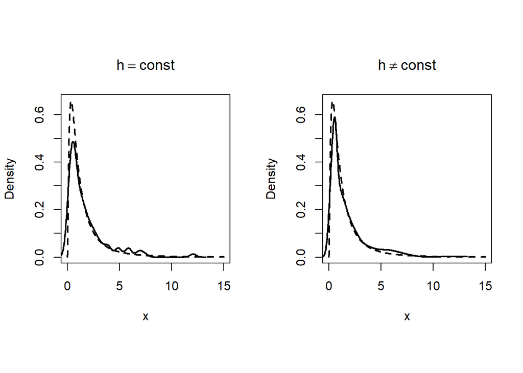

```r
par(mfrow=c(1,2), pty="s")
plot(x, density, "l", lty=2, lwd=2, xlab="x", ylab="Density", main=expression(h == const))
lines(kde.const, col=1, lwd=2)
plot(x, density, "l", lty=2, lwd=2, xlab="x", ylab="Density", main=expression(h != const))
lines(kde.const$eval.points, kde.sp, col=1, lwd=2)
```

## Problem 3 (Homework 8.4)

Reade accessory materials. Write program to realize the result in 39 pages of slide. (Reading material, Figure 3)

## Answer 3

For simplicity, take $K$ to be a symmetric probability density with support $[-1,1]$. We choose a quartic kernel (Biweight) $\frac{15}{16}(1-x^2)^2\cdot I(|x|<1)$ , $\int_{-1}^1 K(x) dx = 1$.

And we calculate $a_l(p), b(p), c_l(p), e(p), g(p)$ as described in the reference book as following. These function is calculated simply, details is omited here.

I adjust the integration interval to $[-1+2p, p]$, $K(\cdot)=0$ otherwise, in case of $K_{R1}$.

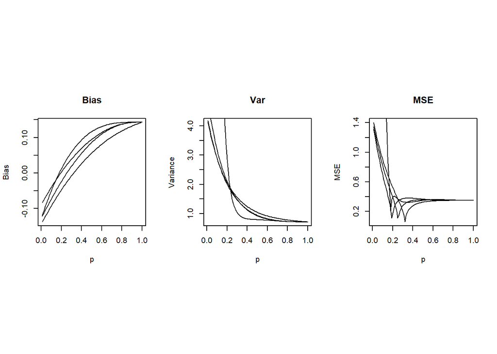

```r
a <- function(p, l=1, d=0){
  if (l==0)
    return(((p + 1)^3*(3*p^2 - 9*p + 8))/16)
  if (l==1)
    return((5*(p^2 - 1)^3)/32)
  if (l==2)
    return((15*p^7)/112 - (3*p^5)/8 + (5*p^3)/16 + 1/14)
}

b <- function(p){
  (5*(p + 1)^5*(35*p^4 - 175*p^3 + 345*p^2 - 325*p + 128))/1792
}

K <- function(x){
  if(x<=1 & x>=-1){
    return(15/16*(1-x^2)^2)
  } else {
    return(0)
    # return(15/16*(1-x^2)^2)
  }
}

c.PD <- function(p, l=1){
  if (l==0)
    return((3*p^5)/4 - (5*p^3)/4 - 1/2)
  if (l==1)
    return((5*(p^2 - 1)^2*(2*p^2 + 1))/16)
  if (l==2)
    return((15*p^7)/28 - (3*p^5)/4 - 3/14)
}

e.PD <- function(p){
  (25*p^9)/64 - (675*p^7)/448 + (135*p^5)/64 - (75*p^3)/64 - 5/28
}

g.PD <- function(p){
  (25*p^9)/16 - (225*p^7)/56 + (45*p^5)/16 + 5/14
}

c.L <- function(p, l=1){
  if (l==0)
    return((5*(p^2 - 1)^3)/32)
  if (l==1)
    return((15*p^7)/112 - (3*p^5)/8 + (5*p^3)/16 + 1/14)
  if (l==2)
    return((5*(p^2 - 1)^3*(3*p^2 + 1))/128)
}

e.L <- function(p){
  (45*(p^2 - 1)^5)/512
}

g.L <- function(p){
  (225*p^11)/2816 - (25*p^9)/64 + (675*p^7)/896 - (45*p^5)/64 + (75*p^3)/256 + 5/154
}

c.D <- function(p, l=1){
  if (l==0)
    return((15*(p^2 - 1)^2)/16)
  if (l==1)
    return((3*p^5)/4 - (5*p^3)/4 - 1/2)
  if (l==2)
    return((5*(p^2 - 1)^2*(2*p^2 + 1))/16)
}

e.D <- function(p){
  (225*(p^2 - 1)^4)/512
}

g.D <- function(p){
  (225*p^7)/112 - (45*p^5)/8 + (75*p^3)/16 + 15/14
}

c.R1 <- function(p, l=1){
  if (l==0) #return(((p + 1)^3*(3*p^2 - 9*p + 8))/16)
    return(-((p - 1)^3*(3*p^2 + 9*p + 8))/16)
    # return(((p + 1)^3*(93*p^2 - 39*p + 8))/16)
  if (l==1) #return(((p + 1)^3*(7*p^3 - 21*p^2 + 17*p + 5))/32)
    return(-((p - 1)^3*(7*p^3 + 21*p^2 + 17*p - 5))/32)
    # return(((p + 1)^3*(57*p^3 - 171*p^2 + 47*p - 5))/32)
  if (l==2) #return(((p + 1)^3*(29*p^4 - 87*p^3 + 62*p^2 + 46*p + 8))/112)
    return(-((p - 1)^3*(29*p^4 + 87*p^3 + 62*p^2 - 46*p + 8))/112)
    # return(((p + 1)^3*(99*p^4 - 297*p^3 + 482*p^2 - 94*p + 8))/112)
}

e.R1 <- function(p){
  # (5*(p + 1)^5*(p^4 - 5*p^3 + 9*p^2 - 5*p + 1))/14
  return(-(5*(p - 1)^5*(p^4 + 5*p^3 + 9*p^2 + 5*p + 1))/14)
  # return((5*(p + 1)^5*(p^4 - 5*p^3 + 9*p^2 - 5*p + 1))/14)
}

g.R1 <- function(p){
  # (5*(p + 1)^5*(17885*p^4 - 8785*p^3 + 3495*p^2 - 955*p + 128))/1792
  return(-(5*(p - 1)^5*(35*p^4 + 175*p^3 + 345*p^2 + 325*p + 128))/1792)
  # return((5*(p + 1)^5*(35*p^4 - 175*p^3 + 345*p^2 - 325*p + 128))/1792)
}

B <- function(p, a, c){
  (c(p,1)*a(p,2) - a(p,1)*c(p,2)) / (c(p,1)*a(p,0) - a(p,1)*c(p,0))
}

V <- function(p, a, b, c, e, g){
  (c(p,1)*c(p,1)*b(p) - 2*c(p,1)*a(p,1)*e(p) + a(p,1)*a(p,1)*g(p)) / (c(p,1)*a(p,0) - a(p,1)*c(p,0))^2
}

MSE <- function(p, B=B, V=V, a=a, b=b, c=c.PD, e=e.PD, g=g.PD){
  ((B(p, a, c)*(V(p, a, b, c, e, g))^2)^2)^(1/5)
}

# Draw the figure
par(mfcol=c(1,3), pty="s")
p <- seq(1,100)/100
# Bias
plot(p, unlist(lapply(p, B, a=a, c=c.PD)), "l", main="Bias", ylab="Bias")
lines(p, unlist(lapply(p, B, a=a, c=c.L)), "l")
lines(p, unlist(lapply(p, B, a=a, c=c.D)), "l")
lines(p, unlist(lapply(p, B, a=a, c=c.R1)), "l")
# Variance
plot(p, unlist(lapply(p, V, a=a, b, c=c.PD, e=e.PD, g=g.PD)), "l", main="Var", ylab="Variance")
lines(p, unlist(lapply(p, V, a=a, b, c=c.L, e=e.L, g=g.L)), "l")
lines(p, unlist(lapply(p, V, a=a, b, c=c.D, e=e.D, g=g.D)), "l")
lines(p, unlist(lapply(p, V, a=a, b, c=c.R1, e=c.R1, g=g.R1)), "l")
# MSE
plot(p, unlist(lapply(p, MSE, B=B, V=V, a=a, b, c=c.PD, e=e.PD, g=g.PD)), "l", main="MSE", ylab="MSE")
lines(p, unlist(lapply(p, MSE, B=B, V=V, a=a, b, c=c.L, e=e.L, g=g.L)), "l")
lines(p, unlist(lapply(p, MSE, B=B, V=V, a=a, b, c=c.D, e=e.D, g=g.D)), "l")
lines(p, unlist(lapply(p, MSE, B=B, V=V, a=a, b, c=c.R1, e=c.R1, g=g.R1)), "l")
```

The funciotn $a(p), b(p), c(p), e(p), g(p)$ are generated by Matlab Symbolic Computation Toolkit, because all of then have the same pattern to integrate. But it does take some time although it has some minor defects.